# Hierarchical PG Analyses: Primary, Sensitivity, and Severity Models

OpenAI

2026-03-20

## Overview

This notebook revises the original `code/analysis/logit.Rmd` workflow to better match the current analytic plan.

### Primary decisions

1. Use a **hierarchical logistic regression** to predict **PG vs HC**.
2. Keep **moderators in Block 4** only.
3. Treat **DOSPERT as domain-specific** in the primary model.
4. **Exclude the gambling domain** from the primary model because of likely criterion overlap with PG status.
5. Treat **investment/financial risk** cautiously. By default, it is excluded from the primary model, but a switch is included below in case you want to add it.
6. Run two follow-up models:
   - a **non-gambling DOSPERT composite** sensitivity model,
   - an **exploratory gambling-domain** model.
7. Run a **within-PG severity analysis** predicting GSAS total.

## Packages

```r
# Core packages expected in most R installations used for this project
library(dplyr)
library(tidyr)
library(ggplot2)
library(knitr)
library(purrr)

# Optional packages: if absent, the notebook falls back to base-R alternatives
have_car      <- requireNamespace("car", quietly = TRUE)
have_broom    <- requireNamespace("broom", quietly = TRUE)
have_pscl     <- requireNamespace("pscl", quietly = TRUE)
have_lmtest   <- requireNamespace("lmtest", quietly = TRUE)
have_sandwich <- requireNamespace("sandwich", quietly = TRUE)

if (have_broom) {
  library(broom)
}
if (have_lmtest) {
  library(lmtest)
}
if (have_sandwich) {
  library(sandwich)
}

cat("Optional packages available:
")
```

```
## Optional packages available:
```

```r
cat("  car      =", have_car, "
")
```

```
##   car      = TRUE
```

```r
cat("  broom    =", have_broom, "
")
```

```
##   broom    = TRUE
```

```r
cat("  pscl     =", have_pscl, "
")
```

```
##   pscl     = TRUE
```

```r
cat("  lmtest   =", have_lmtest, "
")
```

```
##   lmtest   = TRUE
```

```r
cat("  sandwich =", have_sandwich, "
")
```

```
##   sandwich = TRUE
```

## Project paths and data import

```r
# Helper: find the repo root whether knitting from the repo root or from code/analysis/
find_project_root <- function() {
  candidates <- unique(c(
    normalizePath(getwd(), winslash = "/", mustWork = FALSE),
    normalizePath(file.path(getwd(), ".."), winslash = "/", mustWork = FALSE),
    normalizePath(file.path(getwd(), "..", ".."), winslash = "/", mustWork = FALSE)
  ))

  has_required_files <- function(path) {
    file.exists(file.path(path, "derivatives", "scoring", "scoring-mastersheet.csv")) &&
      file.exists(file.path(path, "derivatives", "scoring", "geo-variables.csv"))
  }

  hit <- candidates[vapply(candidates, has_required_files, logical(1))]
  if (length(hit) == 0) {
    stop("Could not locate the project root. Knit this file from the repo root or code/analysis/.")
  }
  hit[[1]]
}

project_root <- find_project_root()
score_path   <- file.path(project_root, "derivatives", "scoring", "scoring-mastersheet.csv")
geo_path     <- file.path(project_root, "derivatives", "scoring", "geo-variables.csv")

df     <- read.csv(score_path)
df_geo <- read.csv(geo_path)
```

## Analysis switches

```r
# Set to TRUE if you want to keep DOSPERT investment/financial risk in the primary model.
include_investment_primary <- FALSE

# Keep this TRUE to match the original repo's outlier handling for relative sensitivity.
apply_original_reward_outlier_filter <- TRUE
```

## Helper functions

```r
z_score <- function(x) as.numeric(scale(x))

safe_confint <- function(model) {
  out <- tryCatch(
    suppressMessages(confint(model)),
    error = function(e) suppressWarnings(confint.default(model))
  )
  out
}

make_or_table <- function(model) {
  est <- coef(model)
  ci  <- safe_confint(model)
  data.frame(
    term = names(est),
    OR = exp(est),
    CI_low = exp(ci[, 1]),
    CI_high = exp(ci[, 2]),
    row.names = NULL
  )
}

make_formula <- function(outcome, block_terms, interactions = NULL) {
  rhs <- c(unlist(block_terms), interactions)
  stats::as.formula(paste(outcome, "~", paste(rhs, collapse = " + ")))
}

fit_block_models <- function(data, outcome, blocks, interactions = NULL, family_obj = binomial()) {
  formulas <- list(
    m1 = make_formula(outcome, blocks[1]),
    m2 = make_formula(outcome, blocks[1:2]),
    m3 = make_formula(outcome, blocks[1:3]),
    m4 = make_formula(outcome, blocks[1:3], interactions = interactions)
  )

  models <- purrr::map(
    formulas,
    ~ glm(.x, data = data, family = family_obj, control = glm.control(maxit = 100))
  )
  list(models = models, formulas = formulas)
}

get_mcfadden <- function(model) {
  # Avoid pscl::pR2() here. In models fit inside a helper, the stored call can
  # retain a symbolic family argument, which causes update()-based null-model
  # refits to fail even when the model itself fit successfully.
  ll_full <- tryCatch(as.numeric(logLik(model)), error = function(e) NA_real_)

  ll_null <- tryCatch({
    nd <- model$null.deviance
    if (is.null(nd) || is.na(nd)) stop("null.deviance unavailable")
    -0.5 * nd
  }, error = function(e) {
    mf <- model.frame(model)
    y  <- model.response(mf)
    null_fit <- glm(y ~ 1, data = mf, family = model$family)
    as.numeric(logLik(null_fit))
  })

  if (is.na(ll_full) || is.na(ll_null) || ll_null == 0) {
    return(NA_real_)
  }

  1 - (ll_full / ll_null)
}

compare_block_models <- function(model_list) {
  list(
    block_1_vs_2 = anova(model_list$m1, model_list$m2, test = "Chisq"),
    block_2_vs_3 = anova(model_list$m2, model_list$m3, test = "Chisq"),
    block_3_vs_4 = anova(model_list$m3, model_list$m4, test = "Chisq"),
    AIC = AIC(model_list$m1, model_list$m2, model_list$m3, model_list$m4),
    BIC = BIC(model_list$m1, model_list$m2, model_list$m3, model_list$m4),
    pR2 = tibble(
      model = c("m1", "m2", "m3", "m4"),
      McFadden = c(
        get_mcfadden(model_list$m1),
        get_mcfadden(model_list$m2),
        get_mcfadden(model_list$m3),
        get_mcfadden(model_list$m4)
      )
    )
  )
}

manual_vif <- function(model) {
  mm <- model.matrix(model)
  assign_vec <- attr(mm, "assign")
  term_labels <- attr(terms(model), "term.labels")

  keep <- colnames(mm) != "(Intercept)"
  mm <- mm[, keep, drop = FALSE]
  assign_vec <- assign_vec[keep]

  out <- lapply(seq_along(term_labels), function(i) {
    cols_i <- which(assign_vec == i)
    if (length(cols_i) == 0) return(NULL)

    Xi <- mm[, cols_i, drop = FALSE]
    Xo <- mm[, -cols_i, drop = FALSE]

    if (ncol(Xi) == 1) {
      fit <- lm(Xi[, 1] ~ Xo)
      r2 <- summary(fit)$r.squared
      data.frame(term = term_labels[i], VIF = 1 / (1 - r2))
    } else {
      r2_vec <- apply(Xi, 2, function(y) summary(lm(y ~ Xo))$r.squared)
      data.frame(term = term_labels[i], VIF = max(1 / (1 - r2_vec)))
    }
  })

  dplyr::bind_rows(out)
}

show_vif <- function(model) {
  if (have_car) {
    return(car::vif(model))
  }
  message("Package 'car' not installed; showing fallback VIF estimates.")
  manual_vif(model)
}

show_vif_predictor <- function(model) {
  if (have_car) {
    return(car::vif(model, type = "predictor"))
  }
  message("Package 'car' not installed; showing fallback VIF estimates for model terms.")
  manual_vif(model)
}

coef_table <- function(model, exponentiate = FALSE) {
  if (have_broom) {
    out <- broom::tidy(model, conf.int = TRUE, exponentiate = exponentiate)
  } else {
    sm <- summary(model)$coefficients
    ci <- safe_confint(model)
    out <- data.frame(
      term = rownames(sm),
      estimate = sm[, 1],
      std.error = sm[, 2],
      statistic = sm[, 3],
      p.value = sm[, 4],
      conf.low = ci[, 1],
      conf.high = ci[, 2],
      row.names = NULL
    )
    if (exponentiate) {
      out$estimate  <- exp(out$estimate)
      out$conf.low  <- exp(out$conf.low)
      out$conf.high <- exp(out$conf.high)
    }
  }
  out
}

robust_coef_test <- function(model) {
  if (have_lmtest && have_sandwich) {
    return(lmtest::coeftest(model, vcov = sandwich::vcovHC(model, type = "HC3")))
  }
  message("Packages 'lmtest' and/or 'sandwich' not installed; returning conventional coefficient table.")
  summary(model)$coefficients
}
```

## Preprocessing

```r
# Reward sensitivity composites from the original repo
# (kept here so this notebook stays aligned with Cooper's prior workflow)
df$bisbas_bas <- df$bisbas_drive + df$bisbas_fun_seek + df$bisbas_reward_res

df$bisbas_bas_z_score <- z_score(df$bisbas_bas)
df$spsrq_sr_z_score   <- z_score(df$spsrq_sr)
df$rs_standard        <- df$bisbas_bas_z_score - df$spsrq_sr_z_score

if (apply_original_reward_outlier_filter) {
  q3 <- quantile(df$rs_standard, 0.75, na.rm = TRUE)
  q1 <- quantile(df$rs_standard, 0.25, na.rm = TRUE)
  iqr_value <- q3 - q1
  upper_bound <- q3 + 1.5 * iqr_value
  lower_bound <- q1 - 1.5 * iqr_value

  df <- df[!(df$rs_standard >= upper_bound | df$rs_standard <= lower_bound) | is.na(df$rs_standard), ]
}

df$rew_composite <- df$spsrq_sr_z_score + df$bisbas_bas_z_score

# Merge geographic/contextual variables
# Note: use the geo file already in the repo rather than refetching ACS data.
df <- df %>%
  left_join(df_geo, by = "ResponseId") %>%
  mutate(across(everything(), ~ ifelse(. == -999, NA, .)))

# Define gambling groups cleanly
# HC: non-gambling / minimal symptoms
# PG: problem gambling criteria met
# Mid: everyone in between, excluded from binary case-control analyses
df <- df %>%
  mutate(
    pg_group = case_when(
      sogs_total >= 1 & bbgs_total >= 4 & (mandf_casinog + mandf_onlineg) >= 1 ~ "PG",
      sogs_total == 0 & bbgs_total <= 3 & (mandf_casinog + mandf_onlineg) == 0 ~ "HC",
      TRUE ~ "Mid"
    ),
    pg_group = factor(pg_group, levels = c("HC", "Mid", "PG")),
    PG = ifelse(pg_group == "PG", 1L, 0L),
    gender = factor(demo_gender, levels = c(1, 2), labels = c("Male", "Female")),
    income_median_split = factor(
      ifelse(ses_tpi <= 2, "Below Median (<$40k)", "Above Median (≥$40k)"),
      levels = c("Below Median (<$40k)", "Above Median (≥$40k)")
    )
  )
```

## Build the HC vs PG analytic dataset

```r
# Start from the case-control comparison only
# and require complete data on all variables needed downstream.
dat_binary <- df %>%
  filter(pg_group %in% c("HC", "PG")) %>%
  drop_na(
    PG, gender, income_median_split,
    TotalCrime, unemployed, Gini,
    demo_yrs,
    rew_composite,
    dospert_gam, dospert_inv, dospert_hs, dospert_soc, dospert_ethic, dospert_rec,
    susd_depression, susd_mania, scared_total, uclal_total,
    gsas_total
  ) %>%
  mutate(
    income = income_median_split,

    # Context
    z_crime = z_score(TotalCrime),
    z_unemp = z_score(unemployed),
    z_gini  = z_score(Gini),
    z_neigh_disadv = rowMeans(cbind(z_crime, z_unemp, z_gini), na.rm = TRUE),

    # Demographics
    z_age = z_score(demo_yrs),

    # Reward sensitivity
    z_reward = z_score(rew_composite),

    # DOSPERT domains
    z_dospert_gam   = z_score(dospert_gam),
    z_dospert_inv   = z_score(dospert_inv),
    z_dospert_hs    = z_score(dospert_hs),
    z_dospert_soc   = z_score(dospert_soc),
    z_dospert_ethic = z_score(dospert_ethic),
    z_dospert_rec   = z_score(dospert_rec),

    # Clinical / social
    z_depression = z_score(susd_depression),
    z_mania      = z_score(susd_mania),
    z_anxiety    = z_score(scared_total),
    z_loneliness = z_score(uclal_total),

    # Sensitivity variants
    dospert_nongam_primary_raw = if (include_investment_primary) {
      rowMeans(cbind(dospert_hs, dospert_soc, dospert_ethic, dospert_rec, dospert_inv), na.rm = FALSE)
    } else {
      rowMeans(cbind(dospert_hs, dospert_soc, dospert_ethic, dospert_rec), na.rm = FALSE)
    },
    z_dospert_nongam_comp = z_score(dospert_nongam_primary_raw),
    z_dospert_total       = z_score(dospert_gam + dospert_inv + dospert_hs + dospert_soc + dospert_ethic + dospert_rec)
  ) %>%
  filter(gender %in% c("Male", "Female"))

cat("Binary analytic N =", nrow(dat_binary), "\n")
```

```
## Binary analytic N = 603
```

```r
cat("HC =", sum(dat_binary$PG == 0), "\n")
```

```
## HC = 406
```

```r
cat("PG =", sum(dat_binary$PG == 1), "\n")
```

```
## PG = 197
```

## Inspect DOSPERT overlap before modeling

```r
dospert_terms_for_corr <- c(
  "z_dospert_hs", "z_dospert_soc", "z_dospert_ethic", "z_dospert_rec", "z_dospert_inv", "z_dospert_gam"
)

round(cor(dat_binary[, dospert_terms_for_corr], use = "pairwise.complete.obs"), 2)
```

```
##                 z_dospert_hs z_dospert_soc z_dospert_ethic z_dospert_rec
## z_dospert_hs            1.00          0.87            0.89          0.86
## z_dospert_soc           0.87          1.00            0.89          0.87
## z_dospert_ethic         0.89          0.89            1.00          0.88
## z_dospert_rec           0.86          0.87            0.88          1.00
## z_dospert_inv           0.87          0.84            0.89          0.84
## z_dospert_gam           0.86          0.81            0.88          0.82
##                 z_dospert_inv z_dospert_gam
## z_dospert_hs             0.87          0.86
## z_dospert_soc            0.84          0.81
## z_dospert_ethic          0.89          0.88
## z_dospert_rec            0.84          0.82
## z_dospert_inv            1.00          0.85
## z_dospert_gam            0.85          1.00
```

## Define model blocks

```r
primary_dospert_terms <- c("z_dospert_hs", "z_dospert_soc", "z_dospert_ethic", "z_dospert_rec")
if (include_investment_primary) {
  primary_dospert_terms <- c(primary_dospert_terms, "z_dospert_inv")
}

block_1 <- c("z_neigh_disadv", "gender", "z_age", "income")
block_2_primary <- c("z_reward", primary_dospert_terms)
block_2_comp    <- c("z_reward", "z_dospert_nongam_comp")
block_2_total   <- c("z_reward", "z_dospert_total")
block_2_explor  <- c("z_reward", primary_dospert_terms, "z_dospert_gam")
block_3 <- c("z_depression", "z_mania", "z_anxiety", "z_loneliness")
block_4_interactions <- c("z_reward:z_loneliness", "z_reward:z_age")
```

## Primary hierarchical logistic regression: non-gambling DOSPERT domains

```r
primary_fit <- fit_block_models(
  data = dat_binary,
  outcome = "PG",
  blocks = list(block_1, block_2_primary, block_3),
  interactions = block_4_interactions,
  family_obj = binomial(link = "logit")
)

m1_primary <- primary_fit$models$m1
m2_primary <- primary_fit$models$m2
m3_primary <- primary_fit$models$m3
m4_primary <- primary_fit$models$m4
```

```r
compare_primary <- compare_block_models(primary_fit$models)
compare_primary$block_1_vs_2
```

```
## Analysis of Deviance Table
##
## Model 1: PG ~ z_neigh_disadv + gender + z_age + income
## Model 2: PG ~ z_neigh_disadv + gender + z_age + income + z_reward + z_dospert_hs +
##     z_dospert_soc + z_dospert_ethic + z_dospert_rec
##   Resid. Df Resid. Dev Df Deviance  Pr(>Chi)
## 1       598     461.48
## 2       593     330.92  5   130.56 < 2.2e-16 ***
## ---
## Signif. codes:  0 '***' 0.001 '**' 0.01 '*' 0.05 '.' 0.1 ' ' 1
```

```r
compare_primary$block_2_vs_3
```

```
## Analysis of Deviance Table
##
## Model 1: PG ~ z_neigh_disadv + gender + z_age + income + z_reward + z_dospert_hs +
##     z_dospert_soc + z_dospert_ethic + z_dospert_rec
## Model 2: PG ~ z_neigh_disadv + gender + z_age + income + z_reward + z_dospert_hs +
##     z_dospert_soc + z_dospert_ethic + z_dospert_rec + z_depression +
##     z_mania + z_anxiety + z_loneliness
##   Resid. Df Resid. Dev Df Deviance Pr(>Chi)
## 1       593     330.92
## 2       589     323.76  4   7.1623   0.1276
```

```r
compare_primary$block_3_vs_4
```

```
## Analysis of Deviance Table
##
## Model 1: PG ~ z_neigh_disadv + gender + z_age + income + z_reward + z_dospert_hs +
##     z_dospert_soc + z_dospert_ethic + z_dospert_rec + z_depression +
##     z_mania + z_anxiety + z_loneliness
## Model 2: PG ~ z_neigh_disadv + gender + z_age + income + z_reward + z_dospert_hs +
##     z_dospert_soc + z_dospert_ethic + z_dospert_rec + z_depression +
##     z_mania + z_anxiety + z_loneliness + z_reward:z_loneliness +
##     z_reward:z_age
##   Resid. Df Resid. Dev Df Deviance Pr(>Chi)
## 1       589     323.76
## 2       587     323.73  2 0.027572   0.9863
```

```r
compare_primary$AIC
```

```
##               df      AIC
## model_list$m1  5 471.4761
## model_list$m2 10 350.9179
## model_list$m3 14 351.7556
## model_list$m4 16 355.7280
```

```r
compare_primary$BIC
```

```
##               df      BIC
## model_list$m1  5 493.4857
## model_list$m2 10 394.9371
## model_list$m3 14 413.3824
## model_list$m4 16 426.1587
```

```r
compare_primary$pR2
```

```
## # A tibble: 4 × 2
##   model McFadden
##   <chr>    <dbl>
## 1 m1       0.394
## 2 m2       0.566
## 3 m3       0.575
## 4 m4       0.575
```

```r
# Main-effects VIF is the most interpretable first pass.
show_vif(m3_primary)
```

```
##  z_neigh_disadv          gender           z_age          income        z_reward
##        1.070151        1.096448        1.354786        1.143839        1.187206
##    z_dospert_hs   z_dospert_soc z_dospert_ethic   z_dospert_rec    z_depression
##        3.297218        3.132951        3.953858        3.368770        2.488972
##         z_mania       z_anxiety    z_loneliness
##        1.868839        2.441479        1.567703
```

```r
# For the interaction model, use predictor-level VIF when car is available.
show_vif_predictor(m4_primary)
```

[output not shown]

```r
primary_or <- make_or_table(m4_primary)
primary_or
```

```
##                          term        OR    CI_low   CI_high
## 1                 (Intercept) 0.2253591 0.1235863 0.3946867
## 2              z_neigh_disadv 2.3778198 1.6017513 3.6227970
## 3                genderFemale 0.4349035 0.2400470 0.7821119
## 4                       z_age 0.5158152 0.3314370 0.7848159
## 5  incomeAbove Median (≥$40k) 1.8691686 1.0274239 3.4101223
## 6                    z_reward 1.8642888 1.1655527 3.0658637
## 7                z_dospert_hs 0.8965777 0.4707921 1.6969311
## 8               z_dospert_soc 1.6977236 0.8910648 3.2798679
## 9             z_dospert_ethic 1.8127224 0.8677831 3.9091239
## 10              z_dospert_rec 1.5040017 0.7721987 2.9560932
## 11               z_depression 1.3601538 0.8362862 2.2232255
## 12                    z_mania 1.3946314 0.8952682 2.1802998
## 13                  z_anxiety 0.8495248 0.5253200 1.3467756
## 14               z_loneliness 0.7693663 0.5124542 1.1322528
## 15      z_reward:z_loneliness 0.9771782 0.6614101 1.4716419
## 16             z_age:z_reward 1.0217849 0.6240658 1.7169608
```

```r
robust_coef_test(m4_primary)
```

```
##
## z test of coefficients:
##
##                             Estimate Std. Error z value  Pr(>|z|)
## (Intercept)                -1.490060   0.285878 -5.2122 1.866e-07 ***
## z_neigh_disadv              0.866184   0.210992  4.1053 4.038e-05 ***
## genderFemale               -0.832631   0.312475 -2.6646  0.007707 **
## z_age                      -0.662007   0.220227 -3.0060  0.002647 **
## incomeAbove Median (≥$40k)  0.625494   0.299067  2.0915  0.036484 *
## z_reward                    0.622880   0.254087  2.4514  0.014229 *
## z_dospert_hs               -0.109170   0.341591 -0.3196  0.749276
## z_dospert_soc               0.529288   0.402981  1.3134  0.189038
## z_dospert_ethic             0.594830   0.394699  1.5070  0.131799
## z_dospert_rec               0.408129   0.324190  1.2589  0.208059
## z_depression                0.307598   0.254336  1.2094  0.226503
## z_mania                     0.332630   0.229151  1.4516  0.146620
## z_anxiety                  -0.163078   0.259313 -0.6289  0.529425
## z_loneliness               -0.262188   0.228966 -1.1451  0.252170
## z_reward:z_loneliness      -0.023086   0.218048 -0.1059  0.915680
## z_age:z_reward              0.021551   0.264605  0.0814  0.935087
## ---
## Signif. codes:  0 '***' 0.001 '**' 0.01 '*' 0.05 '.' 0.1 ' ' 1
```

```r
coef_table(m4_primary, exponentiate = TRUE) %>%
  mutate(
    across(c(estimate, conf.low, conf.high), ~ round(., 3)),
    p.value = round(p.value, 3),
    sig = case_when(
      p.value < .001 ~ "***",
      p.value < .01  ~ "**",
      p.value < .05  ~ "*",
      p.value < .10  ~ ".",
      TRUE ~ ""
    )
  ) %>%
  rename(OR = estimate, CI_low = conf.low, CI_high = conf.high) %>%
  kable()
```

| term | OR | std.error | statistic | p.value | CI_low | CI_high | sig |
| --- | --- | --- | --- | --- | --- | --- | --- |
| (Intercept) | 0.225 | 0.2952541 | -5.0467048 | 0.000 | 0.124 | 0.395 | *** |
| z_neigh_disadv | 2.378 | 0.2075683 | 4.1730070 | 0.000 | 1.602 | 3.623 | *** |
| genderFemale | 0.435 | 0.3003888 | -2.7718449 | 0.006 | 0.240 | 0.782 | ** |
| z_age | 0.516 | 0.2187334 | -3.0265466 | 0.002 | 0.331 | 0.785 | ** |
| incomeAbove Median (≥$40k) | 1.869 | 0.3051323 | 2.0499101 | 0.040 | 1.027 | 3.410 | * |
| z_reward | 1.864 | 0.2459459 | 2.5325878 | 0.011 | 1.166 | 3.066 | * |
| z_dospert_hs | 0.897 | 0.3260246 | -0.3348531 | 0.738 | 0.471 | 1.697 |  |
| z_dospert_soc | 1.698 | 0.3312334 | 1.5979316 | 0.110 | 0.891 | 3.280 |  |
| z_dospert_ethic | 1.813 | 0.3828717 | 1.5536009 | 0.120 | 0.868 | 3.909 |  |
| z_dospert_rec | 1.504 | 0.3413612 | 1.1955939 | 0.232 | 0.772 | 2.956 |  |
| z_depression | 1.360 | 0.2480763 | 1.2399325 | 0.215 | 0.836 | 2.223 |  |
| z_mania | 1.395 | 0.2262882 | 1.4699400 | 0.142 | 0.895 | 2.180 |  |
| z_anxiety | 0.850 | 0.2391861 | -0.6818048 | 0.495 | 0.525 | 1.347 |  |
| z_loneliness | 0.769 | 0.2015569 | -1.3008144 | 0.193 | 0.512 | 1.132 |  |
| z_reward:z_loneliness | 0.977 | 0.2031707 | -0.1136297 | 0.910 | 0.661 | 1.472 |  |
| z_age:z_reward | 1.022 | 0.2575313 | 0.0836829 | 0.933 | 0.624 | 1.717 |  |

## Sensitivity model: non-gambling DOSPERT composite

```r
comp_fit <- fit_block_models(
  data = dat_binary,
  outcome = "PG",
  blocks = list(block_1, block_2_comp, block_3),
  interactions = block_4_interactions,
  family_obj = binomial(link = "logit")
)

m4_comp <- comp_fit$models$m4
compare_comp <- compare_block_models(comp_fit$models)
compare_comp$block_1_vs_2
```

```
## Analysis of Deviance Table
##
## Model 1: PG ~ z_neigh_disadv + gender + z_age + income
## Model 2: PG ~ z_neigh_disadv + gender + z_age + income + z_reward + z_dospert_nongam_comp
##   Resid. Df Resid. Dev Df Deviance  Pr(>Chi)
## 1       598     461.48
## 2       596     332.39  2   129.09 < 2.2e-16 ***
## ---
## Signif. codes:  0 '***' 0.001 '**' 0.01 '*' 0.05 '.' 0.1 ' ' 1
```

```r
compare_comp$block_2_vs_3
```

```
## Analysis of Deviance Table
##
## Model 1: PG ~ z_neigh_disadv + gender + z_age + income + z_reward + z_dospert_nongam_comp
## Model 2: PG ~ z_neigh_disadv + gender + z_age + income + z_reward + z_dospert_nongam_comp +
##     z_depression + z_mania + z_anxiety + z_loneliness
##   Resid. Df Resid. Dev Df Deviance Pr(>Chi)
## 1       596     332.39
## 2       592     325.89  4      6.5   0.1648
```

```r
compare_comp$block_3_vs_4
```

```
## Analysis of Deviance Table
##
## Model 1: PG ~ z_neigh_disadv + gender + z_age + income + z_reward + z_dospert_nongam_comp +
##     z_depression + z_mania + z_anxiety + z_loneliness
## Model 2: PG ~ z_neigh_disadv + gender + z_age + income + z_reward + z_dospert_nongam_comp +
##     z_depression + z_mania + z_anxiety + z_loneliness + z_reward:z_loneliness +
##     z_reward:z_age
##   Resid. Df Resid. Dev Df Deviance Pr(>Chi)
## 1       592     325.89
## 2       590     325.84  2 0.052069   0.9743
```

```r
compare_comp$AIC
```

```
##               df      AIC
## model_list$m1  5 471.4761
## model_list$m2  7 346.3892
## model_list$m3 11 347.8892
## model_list$m4 13 351.8372
```

```r
compare_comp$pR2
```

```
## # A tibble: 4 × 2
##   model McFadden
##   <chr>    <dbl>
## 1 m1       0.394
## 2 m2       0.564
## 3 m3       0.572
## 4 m4       0.572
```

## Exploratory model: add the gambling domain back in

```r
explor_fit <- fit_block_models(
  data = dat_binary,
  outcome = "PG",
  blocks = list(block_1, block_2_explor, block_3),
  interactions = block_4_interactions,
  family_obj = binomial(link = "logit")
)

m4_explor <- explor_fit$models$m4
compare_explor <- compare_block_models(explor_fit$models)
compare_explor$block_1_vs_2
```

```
## Analysis of Deviance Table
##
## Model 1: PG ~ z_neigh_disadv + gender + z_age + income
## Model 2: PG ~ z_neigh_disadv + gender + z_age + income + z_reward + z_dospert_hs +
##     z_dospert_soc + z_dospert_ethic + z_dospert_rec + z_dospert_gam
##   Resid. Df Resid. Dev Df Deviance  Pr(>Chi)
## 1       598     461.48
## 2       592     320.15  6   141.33 < 2.2e-16 ***
## ---
## Signif. codes:  0 '***' 0.001 '**' 0.01 '*' 0.05 '.' 0.1 ' ' 1
```

```r
compare_explor$block_2_vs_3
```

```
## Analysis of Deviance Table
##
## Model 1: PG ~ z_neigh_disadv + gender + z_age + income + z_reward + z_dospert_hs +
##     z_dospert_soc + z_dospert_ethic + z_dospert_rec + z_dospert_gam
## Model 2: PG ~ z_neigh_disadv + gender + z_age + income + z_reward + z_dospert_hs +
##     z_dospert_soc + z_dospert_ethic + z_dospert_rec + z_dospert_gam +
##     z_depression + z_mania + z_anxiety + z_loneliness
##   Resid. Df Resid. Dev Df Deviance Pr(>Chi)
## 1       592     320.15
## 2       588     312.99  4   7.1553   0.1279
```

```r
compare_explor$block_3_vs_4
```

```
## Analysis of Deviance Table
##
## Model 1: PG ~ z_neigh_disadv + gender + z_age + income + z_reward + z_dospert_hs +
##     z_dospert_soc + z_dospert_ethic + z_dospert_rec + z_dospert_gam +
##     z_depression + z_mania + z_anxiety + z_loneliness
## Model 2: PG ~ z_neigh_disadv + gender + z_age + income + z_reward + z_dospert_hs +
##     z_dospert_soc + z_dospert_ethic + z_dospert_rec + z_dospert_gam +
##     z_depression + z_mania + z_anxiety + z_loneliness + z_reward:z_loneliness +
##     z_reward:z_age
##   Resid. Df Resid. Dev Df Deviance Pr(>Chi)
## 1       588     312.99
## 2       586     312.97  2 0.019501   0.9903
```

```r
compare_explor$AIC
```

```
##               df      AIC
## model_list$m1  5 471.4761
## model_list$m2 11 342.1464
## model_list$m3 15 342.9910
## model_list$m4 17 346.9715
```

```r
compare_explor$pR2
```

```
## # A tibble: 4 × 2
##   model McFadden
##   <chr>    <dbl>
## 1 m1       0.394
## 2 m2       0.580
## 3 m3       0.589
## 4 m4       0.589
```

## Optional comparison: total DOSPERT instead of domains

```r
total_fit <- fit_block_models(
  data = dat_binary,
  outcome = "PG",
  blocks = list(block_1, block_2_total, block_3),
  interactions = block_4_interactions,
  family_obj = binomial(link = "logit")
)

m4_total <- total_fit$models$m4
compare_total <- compare_block_models(total_fit$models)
compare_total$AIC
```

```
##               df      AIC
## model_list$m1  5 471.4761
## model_list$m2  7 340.2009
## model_list$m3 11 342.5183
## model_list$m4 13 346.4688
```

```r
compare_total$pR2
```

```
## # A tibble: 4 × 2
##   model McFadden
##   <chr>    <dbl>
## 1 m1       0.394
## 2 m2       0.572
## 3 m3       0.579
## 4 m4       0.579
```

## Compare final models side by side

```r
model_compare <- tibble(
  model = c(
    "Primary: non-gambling domains",
    "Sensitivity: non-gambling composite",
    "Exploratory: add gambling domain",
    "Optional: total DOSPERT"
  ),
  AIC = c(
    AIC(m4_primary),
    AIC(m4_comp),
    AIC(m4_explor),
    AIC(m4_total)
  ),
  BIC = c(
    BIC(m4_primary),
    BIC(m4_comp),
    BIC(m4_explor),
    BIC(m4_total)
  ),
  McFadden = c(
    get_mcfadden(m4_primary),
    get_mcfadden(m4_comp),
    get_mcfadden(m4_explor),
    get_mcfadden(m4_total)
  )
)

model_compare %>%
  mutate(across(where(is.numeric), ~ round(., 3))) %>%
  kable()
```

| model | AIC | BIC | McFadden |
| --- | --- | --- | --- |
| Primary: non-gambling domains | 355.728 | 426.159 | 0.575 |
| Sensitivity: non-gambling composite | 351.837 | 409.062 | 0.572 |
| Exploratory: add gambling domain | 346.972 | 421.804 | 0.589 |
| Optional: total DOSPERT | 346.469 | 403.694 | 0.579 |

## Predicted probabilities for the primary interaction model

```r
newdat_primary <- expand.grid(
  z_neigh_disadv = 0,
  gender = levels(dat_binary$gender)[1],
  income = levels(dat_binary$income)[1],
  z_age = c(-1, 0, 1),
  z_reward = c(-1, 0, 1),
  z_depression = 0,
  z_mania = 0,
  z_anxiety = 0,
  z_loneliness = c(-1, 0, 1)
)

# Add DOSPERT terms at the mean for prediction.
for (term in primary_dospert_terms) {
  newdat_primary[[term]] <- 0
}

newdat_primary$pred_prob <- predict(m4_primary, newdata = newdat_primary, type = "response")
newdat_primary
```

```
##    z_neigh_disadv gender               income z_age z_reward z_depression
## 1               0   Male Below Median (<$40k)    -1       -1            0
## 2               0   Male Below Median (<$40k)     0       -1            0
## 3               0   Male Below Median (<$40k)     1       -1            0
## 4               0   Male Below Median (<$40k)    -1        0            0
## 5               0   Male Below Median (<$40k)     0        0            0
## 6               0   Male Below Median (<$40k)     1        0            0
## 7               0   Male Below Median (<$40k)    -1        1            0
## 8               0   Male Below Median (<$40k)     0        1            0
## 9               0   Male Below Median (<$40k)     1        1            0
## 10              0   Male Below Median (<$40k)    -1       -1            0
## 11              0   Male Below Median (<$40k)     0       -1            0
## 12              0   Male Below Median (<$40k)     1       -1            0
## 13              0   Male Below Median (<$40k)    -1        0            0
## 14              0   Male Below Median (<$40k)     0        0            0
```

[output cut: 69 more lines]

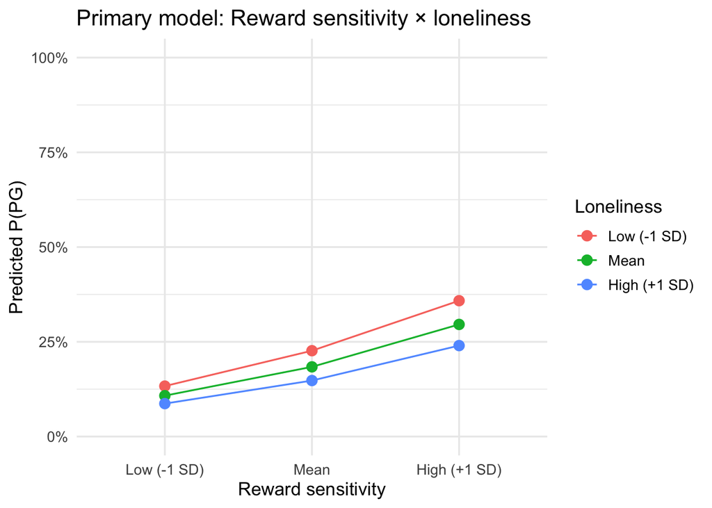

```r
newdat_primary %>%
  filter(z_age == 0) %>%
  mutate(
    Reward = factor(z_reward, labels = c("Low (-1 SD)", "Mean", "High (+1 SD)")),
    Loneliness = factor(z_loneliness, labels = c("Low (-1 SD)", "Mean", "High (+1 SD)"))
  ) %>%
  ggplot(aes(x = Reward, y = pred_prob, group = Loneliness, color = Loneliness)) +
  geom_point(size = 3) +
  geom_line() +
  scale_y_continuous(labels = scales::percent, limits = c(0, 1)) +
  labs(
    x = "Reward sensitivity",
    y = "Predicted P(PG)",
    color = "Loneliness",
    title = "Primary model: Reward sensitivity × loneliness"
  ) +
  theme_minimal(base_size = 13)
```

## Secondary analysis: severity within PG only

```r
dat_pg <- df %>%
  filter(pg_group == "PG") %>%
  drop_na(
    gender, income_median_split,
    TotalCrime, unemployed, Gini,
    demo_yrs,
    rew_composite,
    dospert_gam, dospert_inv, dospert_hs, dospert_soc, dospert_ethic, dospert_rec,
    susd_depression, susd_mania, scared_total, uclal_total,
    gsas_total
  ) %>%
  mutate(
    income = income_median_split,
    z_crime = z_score(TotalCrime),
    z_unemp = z_score(unemployed),
    z_gini  = z_score(Gini),
    z_neigh_disadv = rowMeans(cbind(z_crime, z_unemp, z_gini), na.rm = TRUE),
    z_age = z_score(demo_yrs),
    z_reward = z_score(rew_composite),
    z_dospert_gam   = z_score(dospert_gam),
    z_dospert_inv   = z_score(dospert_inv),
    z_dospert_hs    = z_score(dospert_hs),
    z_dospert_soc   = z_score(dospert_soc),
    z_dospert_ethic = z_score(dospert_ethic),
    z_dospert_rec   = z_score(dospert_rec),
    dospert_nongam_primary_raw = if (include_investment_primary) {
      rowMeans(cbind(dospert_hs, dospert_soc, dospert_ethic, dospert_rec, dospert_inv), na.rm = FALSE)
    } else {
      rowMeans(cbind(dospert_hs, dospert_soc, dospert_ethic, dospert_rec), na.rm = FALSE)
    },
    z_dospert_nongam_comp = z_score(dospert_nongam_primary_raw),
    z_depression = z_score(susd_depression),
    z_mania      = z_score(susd_mania),
    z_anxiety    = z_score(scared_total),
    z_loneliness = z_score(uclal_total),
    z_gsas_total = z_score(gsas_total)
  ) %>%
  filter(gender %in% c("Male", "Female"))

cat("PG severity analytic N =", nrow(dat_pg), "\n")
```

```
## PG severity analytic N = 197
```

```r
# Severity models mirror the logistic structure, but the outcome is GSAS total.
severity_formula_1 <- make_formula("gsas_total", list(block_1))
severity_formula_2 <- make_formula("gsas_total", list(block_1, block_2_primary))
severity_formula_3 <- make_formula("gsas_total", list(block_1, block_2_primary, block_3))
severity_formula_4 <- make_formula("gsas_total", list(block_1, block_2_primary, block_3), interactions = block_4_interactions)

s1 <- lm(severity_formula_1, data = dat_pg)
s2 <- lm(severity_formula_2, data = dat_pg)
s3 <- lm(severity_formula_3, data = dat_pg)
s4 <- lm(severity_formula_4, data = dat_pg)
```

```r
anova(s1, s2, s3, s4)
```

```
## Analysis of Variance Table
##
## Model 1: gsas_total ~ z_neigh_disadv + gender + z_age + income
## Model 2: gsas_total ~ z_neigh_disadv + gender + z_age + income + z_reward +
##     z_dospert_hs + z_dospert_soc + z_dospert_ethic + z_dospert_rec
## Model 3: gsas_total ~ z_neigh_disadv + gender + z_age + income + z_reward +
##     z_dospert_hs + z_dospert_soc + z_dospert_ethic + z_dospert_rec +
##     z_depression + z_mania + z_anxiety + z_loneliness
## Model 4: gsas_total ~ z_neigh_disadv + gender + z_age + income + z_reward +
##     z_dospert_hs + z_dospert_soc + z_dospert_ethic + z_dospert_rec +
##     z_depression + z_mania + z_anxiety + z_loneliness + z_reward:z_loneliness +
##     z_reward:z_age
##   Res.Df     RSS Df Sum of Sq      F    Pr(>F)
## 1    192 11334.5
## 2    187 10362.6  5    971.89 4.0804  0.001557 **
## 3    183  8854.8  4   1507.79 7.9130 6.704e-06 ***
## 4    181  8622.2  2    232.61 2.4415  0.089888 .
## ---
## Signif. codes:  0 '***' 0.001 '**' 0.01 '*' 0.05 '.' 0.1 ' ' 1
```

```r
AIC(s1, s2, s3, s4)
```

```
##    df      AIC
## s1  6 1369.385
## s2 11 1361.725
## s3 15 1338.748
## s4 17 1337.504
```

```r
BIC(s1, s2, s3, s4)
```

```
##    df      BIC
## s1  6 1389.085
## s2 11 1397.840
## s3 15 1387.996
## s4 17 1393.318
```

```r
summary(s4)
```

```
##
## Call:
## lm(formula = severity_formula_4, data = dat_pg)
##
## Residuals:
##      Min       1Q   Median       3Q      Max
## -23.2102  -3.1100   0.0606   3.6438  22.4093
##
## Coefficients:
##                            Estimate Std. Error t value Pr(>|t|)
## (Intercept)                21.19001    1.10307  19.210  < 2e-16 ***
## z_neigh_disadv             -0.70270    0.71767  -0.979 0.328824
## genderFemale               -2.21418    1.18202  -1.873 0.062652 .
## z_age                      -0.44189    0.54859  -0.806 0.421580
## incomeAbove Median (≥$40k)  4.06445    1.19751   3.394 0.000846 ***
## z_reward                    0.81406    0.63599   1.280 0.202184
## z_dospert_hs               -1.89266    1.13043  -1.674 0.095802 .
## z_dospert_soc               0.45422    1.16993   0.388 0.698291
## z_dospert_ethic            -0.65065    1.20069  -0.542 0.588554
## z_dospert_rec               1.91660    1.04988   1.826 0.069567 .
## z_depression                4.02118    0.83345   4.825 2.97e-06 ***
## z_mania                    -1.68268    0.80148  -2.099 0.037163 *
## z_anxiety                   0.11809    0.66606   0.177 0.859472
## z_loneliness                0.06785    0.57203   0.119 0.905716
## z_reward:z_loneliness       1.10112    0.52721   2.089 0.038145 *
## z_age:z_reward             -0.10047    0.41199  -0.244 0.807610
## ---
## Signif. codes:  0 '***' 0.001 '**' 0.01 '*' 0.05 '.' 0.1 ' ' 1
##
## Residual standard error: 6.902 on 181 degrees of freedom
## Multiple R-squared:  0.3062, Adjusted R-squared:  0.2487
## F-statistic: 5.324 on 15 and 181 DF,  p-value: 8.452e-09
```

```r
show_vif(s3)
```

```
##  z_neigh_disadv          gender           z_age          income        z_reward
##        1.087100        1.149250        1.093192        1.191383        1.635341
##    z_dospert_hs   z_dospert_soc z_dospert_ethic   z_dospert_rec    z_depression
##        5.123517        5.595457        5.764050        4.449129        2.837416
##         z_mania       z_anxiety    z_loneliness
##        2.635417        1.810040        1.333760
```

```r
show_vif_predictor(s4)
```

```
##                     GVIF Df GVIF^(1/(2*Df))      Interacts With
## z_neigh_disadv  1.110675  1        1.053886                --
## gender          1.162779  1        1.078322                --
## z_age           2.173579  3        1.138141            z_reward
## income          1.193447  1        1.092450                --
## z_reward        2.737080  5        1.105933 z_loneliness, z_age
## z_dospert_hs    5.257768  1        2.292982                --
## z_dospert_soc   5.631691  1        2.373118                --
## z_dospert_ethic 5.931648  1        2.435497                --
## z_dospert_rec   4.535186  1        2.129598                --
## z_depression    2.858060  1        1.690580                --
## z_mania         2.643039  1        1.625743                --
## z_anxiety       1.825354  1        1.351057                --
## z_loneliness    2.530829  3        1.167375            z_reward
##                                                                                                                                                     Other Predictors
## z_neigh_disadv          gender, z_age, income, z_reward, z_dospert_hs, z_dospert_soc, z_dospert_ethic, z_dospert_rec, z_depression, z_mania, z_anxiety, z_loneliness
## gender          z_neigh_disadv, z_age, income, z_reward, z_dospert_hs, z_dospert_soc, z_dospert_ethic, z_dospert_rec, z_depression, z_mania, z_anxiety, z_loneliness
## z_age                    z_neigh_disadv, gender, income, z_dospert_hs, z_dospert_soc, z_dospert_ethic, z_dospert_rec, z_depression, z_mania, z_anxiety, z_loneliness
## income          z_neigh_disadv, gender, z_age, z_reward, z_dospert_hs, z_dospert_soc, z_dospert_ethic, z_dospert_rec, z_depression, z_mania, z_anxiety, z_loneliness
## z_reward                               z_neigh_disadv, gender, income, z_dospert_hs, z_dospert_soc, z_dospert_ethic, z_dospert_rec, z_depression, z_mania, z_anxiety
## z_dospert_hs          z_neigh_disadv, gender, z_age, income, z_reward, z_dospert_soc, z_dospert_ethic, z_dospert_rec, z_depression, z_mania, z_anxiety, z_loneliness
## z_dospert_soc          z_neigh_disadv, gender, z_age, income, z_reward, z_dospert_hs, z_dospert_ethic, z_dospert_rec, z_depression, z_mania, z_anxiety, z_loneliness
## z_dospert_ethic          z_neigh_disadv, gender, z_age, income, z_reward, z_dospert_hs, z_dospert_soc, z_dospert_rec, z_depression, z_mania, z_anxiety, z_loneliness
## z_dospert_rec          z_neigh_disadv, gender, z_age, income, z_reward, z_dospert_hs, z_dospert_soc, z_dospert_ethic, z_depression, z_mania, z_anxiety, z_loneliness
## z_depression          z_neigh_disadv, gender, z_age, income, z_reward, z_dospert_hs, z_dospert_soc, z_dospert_ethic, z_dospert_rec, z_mania, z_anxiety, z_loneliness
## z_mania          z_neigh_disadv, gender, z_age, income, z_reward, z_dospert_hs, z_dospert_soc, z_dospert_ethic, z_dospert_rec, z_depression, z_anxiety, z_loneliness
## z_anxiety          z_neigh_disadv, gender, z_age, income, z_reward, z_dospert_hs, z_dospert_soc, z_dospert_ethic, z_dospert_rec, z_depression, z_mania, z_loneliness
## z_loneliness                    z_neigh_disadv, gender, z_age, income, z_dospert_hs, z_dospert_soc, z_dospert_ethic, z_dospert_rec, z_depression, z_mania, z_anxiety
```

```r
coef_table(s4, exponentiate = FALSE) %>%
  mutate(
    across(c(estimate, std.error, conf.low, conf.high), ~ round(., 3)),
    p.value = round(p.value, 3),
    sig = case_when(
      p.value < .001 ~ "***",
      p.value < .01  ~ "**",
      p.value < .05  ~ "*",
      p.value < .10  ~ ".",
      TRUE ~ ""
    )
  ) %>%
  kable()
```

| term | estimate | std.error | statistic | p.value | conf.low | conf.high | sig |
| --- | --- | --- | --- | --- | --- | --- | --- |
| (Intercept) | 21.190 | 1.103 | 19.2099617 | 0.000 | 19.013 | 23.367 | *** |
| z_neigh_disadv | -0.703 | 0.718 | -0.9791279 | 0.329 | -2.119 | 0.713 |  |
| genderFemale | -2.214 | 1.182 | -1.8732102 | 0.063 | -4.547 | 0.118 | . |
| z_age | -0.442 | 0.549 | -0.8055141 | 0.422 | -1.524 | 0.641 |  |
| incomeAbove Median (≥$40k) | 4.064 | 1.198 | 3.3940809 | 0.001 | 1.702 | 6.427 | ** |
| z_reward | 0.814 | 0.636 | 1.2799991 | 0.202 | -0.441 | 2.069 |  |
| z_dospert_hs | -1.893 | 1.130 | -1.6742852 | 0.096 | -4.123 | 0.338 | . |
| z_dospert_soc | 0.454 | 1.170 | 0.3882453 | 0.698 | -1.854 | 2.763 |  |
| z_dospert_ethic | -0.651 | 1.201 | -0.5418992 | 0.589 | -3.020 | 1.718 |  |
| z_dospert_rec | 1.917 | 1.050 | 1.8255429 | 0.070 | -0.155 | 3.988 | . |
| z_depression | 4.021 | 0.833 | 4.8247555 | 0.000 | 2.377 | 5.666 | *** |
| z_mania | -1.683 | 0.801 | -2.0994619 | 0.037 | -3.264 | -0.101 | * |
| z_anxiety | 0.118 | 0.666 | 0.1772991 | 0.859 | -1.196 | 1.432 |  |
| z_loneliness | 0.068 | 0.572 | 0.1186099 | 0.906 | -1.061 | 1.197 |  |
| z_reward:z_loneliness | 1.101 | 0.527 | 2.0885723 | 0.038 | 0.061 | 2.141 | * |
| z_age:z_reward | -0.100 | 0.412 | -0.2438672 | 0.808 | -0.913 | 0.712 |  |

## Notes for interpretation

Suggested read of this notebook:

1. Start with the primary logistic model using non-gambling DOSPERT domains.
2. Check whether Block 4 materially improves fit. If not, the main-effects model may be the cleaner result to report.
3. Compare the primary model with the non-gambling composite and exploratory gambling-domain models.
4. Treat the severity models as a different question: what predicts symptom burden among PG cases, not what distinguishes cases from controls.
5. If investment/financial risk looks too gambling-adjacent, keep include_investment_primary = FALSE.